# Single Peptide Results Analysis - UPS Dataset

Caleb Easterly and Ray Sajulga

### Peptide Sampling

Let’s randomly select 10 UPS peptides and 10 non-UPS peptides from the UPS1 dataset (replicate #3):

```r
library(dplyr)
library(stringr)
# Obtains peptide report
peptide_report <- read.csv("Data/UPS/UPS1/UPS1_03_[Peptide_Shaker_on_data_21__Peptide_Report].tabular",
         sep = "\t", comment.char="", header = TRUE, stringsAsFactors = FALSE) %>%
  select(proteins = Protein.s.,
         sequence = Sequence,
         counts = X.Validated.PSMs)

# Splits into UPS peptides and non-UPS peptides
ups_peptides <- filter(peptide_report, grepl("ups", proteins))
non_ups_peptides <- filter(peptide_report, !grepl("ups", proteins))

# Randomly selects 10 from each category
set.seed(1003)
ups_peps_20 <- ups_peptides[sample(nrow(ups_peptides), 10),]
non_ups_peps_20 <- non_ups_peptides[sample(nrow(non_ups_peptides), 10),]
twenty_peps <- rbind(ups_peps_20, non_ups_peps_20)
set.seed(24)
fivepep_df <- twenty_peps[sample(20,5),]
fivepep <- fivepep_df$sequence

# Concatenates the two categories and writes it out in a text file for analysis
write.table(twenty_peps$sequence, "twenty_peptides.txt",
            sep="\n", quote=FALSE, row.names=FALSE, col.names=FALSE)
fivepep_df
```

```
##                       proteins                   sequence counts
## 284  P01375ups; con_TNFA_HUMAN                   VNLLSAIK      5
## 214                  O76070ups               EEVAEEAQSGGD      2
## 5564                    P00961                DPQQIISGNEK      1
## 248  P02768ups; con_ALBU_HUMAN     LVRPEVDVMCTAFHDNEETFLK      3
## 6714                    P0AB71 ENNFALPAVNCVGTDSINAVLETAAK      5
```

### Unipept

#### Process

- Paste the tabular list of peptides into the Unipept ‘Metaproteomics Analysis’ web application (https://morty.ugent.be/mpa)
- Parameters:
  - Equate I and L: FALSE
  - Filter duplicate peptides: FALSE
  - Advanced missed cleavage handling: TRUE
- Download results
- Annotate each peptide with only the GO terms that are present in 5% or more of the proteins (percentages are returned in GO term column)

```r
cov_pat <- "\ \\(.{2,4}\\)"
uni <- read.csv('results/unipept/UPS1_03-Unipept-20pep-1003seed.csv',
                stringsAsFactors = FALSE) %>%
    select(peptide,
           uni_go_bp = GO..biological.process.,
           uni_go_mf = GO..molecular.function.,
           uni_go_cc = GO..cellular.component.) %>%
    filter(peptide %in% fivepep) %>%
    mutate(uni_go_bp = str_replace_all(string = uni_go_bp, pattern = cov_pat, replacement = ""),
           uni_go_mf = str_replace_all(string = uni_go_mf, pattern = cov_pat, replacement = ""),
           uni_go_cc = str_replace_all(string = uni_go_cc, pattern = cov_pat, replacement = ""))
```

### eggNOG mapper

- Use the Galaxy version of eggNOG mapper, on Galaxy-P
- Parameters:
  - Annotation type: DIAMOND
  - Scoring matrix and gap costs: PAM30, 9 and 1
  - Taxonomic Scope: Mammals
  - Orthologs: use all orthologs
  - Gene Ontology evidence: use non-electronic terms
  - Seed Orthology Search Options
    - Min e-value: 200000
    - Min bit score: 20
- Download and compare GO terms

```r
em <- read.delim("results/eggNOG/eggnog_mapper_20_sequences_results_seed-1003.tabular",
                 stringsAsFactors = FALSE,
                 header=FALSE) %>%
    select(peptide = V1, em_prot = V2, em_go = V6, em_gene = V5, em_descript = V13) %>%
    filter(peptide %in% fivepep) %>%
    mutate(em_go = str_replace_all(em_go, pattern = ",", replacement = "; "))
```

## BLASTP against UniProt

- Use the UniProtKB BLAST web search on each peptide, one-by-one
- Parameters
  - Target database: UniProtKB
  - E-Threshold: 10
  - Matrix: Auto
  - Filtering: None
  - Gapped: Yes
  - Hits: 50
- For each peptide, download the result list and get all GO terms and TaxID associated with that peptide
- To match Unipept, annotate each peptide with only the GO terms that are present in 5% or more of the proteins
- Get the most frequent protein name
- For taxonomy, we can also calculate the lowest common ancestor of each peptide (TODO)

```r
peptide <- rep(0, 5)
blast_go <- rep(0, 5)
files <- list.files('results/uniprot_blastp')
for (i in 1:5){
    peptide[i] <- fivepep[i]
    result <- read.delim(paste('results/uniprot_blastp/', paste(fivepep[i], '.tab', sep=""), sep="/"),
                   stringsAsFactors = FALSE,
                   na.strings = c("", "NA", "NaN"))
    gos <- table(unlist(str_split(result$Gene.ontology.IDs, "; ")))/50
    blast_go[i] <- paste(names(gos)[which(gos > 0.05)], collapse = "; ")
}
blast <- data.frame(peptide, blast_go, stringsAsFactors = FALSE)
```

### MetaGOmics

- Upload HOMD to metaGOmics
- Parameters:
  - Uniprot database: Uniprot sprot
  - Blast e-value cutoff: 1e-10
  - Use only top hit?: TRUE
- Result URL: https://www.yeastrc.org/metagomics/viewUploadedFasta.do?uid=qeZUp8gtIJDc4Sgh
- One-by-one, upload peptides and run
- Download results individually, combine into table

```r
# Creates the input files for metaGOmics i.e., single peptide with spectral count (# of validated PSMs)
#go_input <- select(fivepep_df, sequence, counts)
#for (i in 1:nrow(go_input)){
#  write.table(go_input[i,], paste('Data/metaGOmics/', go_input[i,]$sequence,".txt", sep=""),
#            sep="\t", eol = "\r\n", quote=FALSE, row.names=FALSE, col.names=FALSE)
#}

peptide <- rep(0, 5)
mg_go <- rep(0, 5)
dir <- 'results/metaGOmics/'
files <- list.files(dir)
for (i in 1:5){
    peptide[i] <- fivepep[i]
    result <- read.delim(paste(dir, paste(fivepep[i], '.txt', sep=""), sep=""),
                   stringsAsFactors = FALSE,
                   na.strings = c("", "NA", "NaN"),
                   comment.char = "#")
    gos <- result$GO.acc
    mg_go[i] <- paste(gos, collapse = "; ")
}
mg <- data.frame(peptide, mg_go, stringsAsFactors = FALSE)
```

### Combine all of the results:

```r
pepprots <- select(peptide_report, proteins, peptide = sequence) %>%
  filter(peptide %in% fivepep)
all_results <- plyr::join_all(list(pepprots, em, blast, mg, uni), by = "peptide")
all_results
```

[output not shown]

[output cut: 33 more lines]

All of the results are below:

```r
library(pander)
# knitr::kable(all_results)
pander::pander(all_results, split.cell = 80, split.table = Inf)
```

| proteins | peptide | em_prot | em_go | em_gene | em_descript | blast_go | mg_go | uni_go_bp | uni_go_mf | uni_go_cc |
| --- | --- | --- | --- | --- | --- | --- | --- | --- | --- | --- |
| O76070ups | EEVAEEAQSGGD | 9601.ENSPPYP00000002644 | GO:0003008; GO:0005575; GO:0005622; GO:0005623; GO:0005737; GO:0005819; GO:0005856; GO:0007154; GO:0007165; GO:0007267; GO:0007268; GO:0007610; GO:0007626; GO:0008150; GO:0008344; GO:0009987; GO:00106… | SNCG | synuclein, gamma (breast cancer-specific protein 1) | GO:0005737; GO:0007268; GO:0008344; GO:0009306; GO:0014059; GO:0030424; GO:0043025; GO:0046928; GO:0050808 | GO:0016043; GO:0044464; GO:0032940; GO:0046928; GO:0051588; GO:0044070; GO:0006810; GO:0007267; GO:0005856; GO:0008104; GO:0048471; GO:0043269; GO:0008150; GO:0097458; GO:0014059; GO:0051179; GO:00700… | GO:0008344;GO:0050808;GO:0014059 |  | GO:0005737;GO:0030424;GO:0043025 |
| P00961 | DPQQIISGNEK | 469008.ECD_03410 |  |  | Glycyl-tRNA synthetase beta subunit | GO:0004814; GO:0004820; GO:0005524; GO:0005737; GO:0006420; GO:0006426 | GO:0044464; GO:0006399; GO:0006807; GO:1901360; GO:0004812; GO:1901363; GO:0004814; GO:0019752; GO:0004820; GO:0006412; GO:0016070; GO:0046483; GO:0006418; GO:0006139; GO:0032549; GO:0032550; GO:00064… | GO:0006426;GO:0006420 | GO:0004820;GO:0005524;GO:0004814 | GO:0005737;GO:0005829 |
| P02768ups; con_ALBU_HUMAN | LVRPEVDVMCTAFHDNEETFLK | 9601.ENSPPYP00000016551 | GO:0001775; GO:0001897; GO:0001906; GO:0001907; GO:0002576; GO:0003008; GO:0003013; GO:0003018; GO:0003674; GO:0003676; GO:0003677; GO:0005488; GO:0005504; GO:0005507; GO:0005575; GO:0005576; GO:00055… | ALB | serum albumin | GO:0003677; GO:0005504; GO:0005615; GO:0005783; GO:0005794; GO:0009267; GO:0015643; GO:0019825; GO:0019836; GO:0030170; GO:0032991; GO:0042802; GO:0043066; GO:0043209; GO:0046872; GO:0051087; GO:00516… | GO:0090066; GO:0032940; GO:0043252; GO:1901363; GO:0015643; GO:0008144; GO:0016209; GO:0002576; GO:0008150; GO:0072562; GO:0044364; GO:0005604; GO:0071496; GO:0036094; GO:0005615; GO:0032991; GO:00516… | GO:0019836;GO:0051659;GO:0009267 | GO:0003677;GO:0015643;GO:0051087 | GO:0005615;GO:0005794;GO:0005783 |
| P0AB71 | ENNFALPAVNCVGTDSINAVLETAAK | 469008.B21_02719 |  |  | fructose-bisphosphate aldolase | GO:0004332; GO:0006096; GO:0008270 | GO:0009205; GO:1901360; GO:0016829; GO:0016830; GO:0046939; GO:0016832; GO:0006139; GO:0008150; GO:0006163; GO:0042278; GO:0046364; GO:0019362; GO:0019637; GO:1901135; GO:1901657; GO:0006165; GO:00461… | GO:0006096;GO:0006094 | GO:0008270;GO:0004332;GO:0042802 | GO:0005886;GO:0005829;GO:0005618 |
| P01375ups; con_TNFA_HUMAN | VNLLSAIK | NA | NA | NA | NA |  | GO:0031328; GO:0031329; GO:0031331; GO:0060627; GO:0031334; GO:1902930; GO:1902932; GO:0031347; GO:0007249; GO:0010803; GO:0031349; GO:0002573; GO:1901888; GO:1901889; GO:0007254; GO:2000303; GO:00516… | GO:0006955;GO:0097527;GO:0051092 | GO:0005125;GO:0005164;GO:0002020 | GO:0005615;GO:0016021;GO:0016020 |

## Let’s go through the peptides one-by-one

```r
n <- 1
all_results[n, 'peptide']
```

```
## [1] "EEVAEEAQSGGD"
```

```r
all_results[n, 'proteins']
```

```
## [1] "O76070ups"
```

```r
buni <- all_results[n, 'blast_go']
buni
```

```
## [1] "GO:0005737; GO:0007268; GO:0008344; GO:0009306; GO:0014059; GO:0030424; GO:0043025; GO:0046928; GO:0050808"
```

This is the metaGOmics list:

```r
metaGOmics_list <- c(str_split(all_results[n, 'mg_go'], "; ", simplify=TRUE))
```

And eggNOG

```r
eggnog_list <- c(str_split(all_results[n, 'em_go'], "; ", simplify =TRUE))
```

```r
library(httr)
library(jsonlite)
buni_split <- str_split(buni, "; ", simplify = TRUE)
get_go_names <- function(id_vector){
    base_url <- 'https://www.ebi.ac.uk/QuickGO/services/ontology/go/terms/'
    terms <- str_replace(id_vector, ":", "%3A")
    joined_terms <- paste(terms, collapse="%2C")
    term_url <- paste(base_url, joined_terms, sep="")
    term_info <- GET(term_url, accept("application/json"))
    json <- toJSON(content(term_info))
    names <- unlist(fromJSON(json)$results$name)
    names
}
get_go_names(buni_split)
```

[output not shown]

```r
em_buni <- intersect(eggnog_list, buni_split)
em_num_buni <- length(em_buni)
em_num_buni == 4
```

```
## [1] FALSE
```

```r
mg_buni <- intersect(metaGOmics_list, buni_split)
mg_num_buni <- length(mg_buni)
mg_num_buni == 4
```

```
## [1] FALSE
```

The question is, then, what the other terms are.

1. original terms (BLAST terms)
2. ancestors
3. descendants
4. children of ancestors
5. extraneous

### Ancestors

```r
# get all ancestors of the 4 terms
get_go_ancestors <- function(id_vector){
    base_url <- 'https://www.ebi.ac.uk/QuickGO/services/ontology/go/terms/'
    terms <- str_replace(id_vector, ":", "%3A")
    joined_terms <- paste(terms, collapse="%2C")
    term_url <- paste(base_url, joined_terms, '/ancestors?relations=is_a', sep="")
    term_info <- GET(term_url, accept("application/json"))
    json <- toJSON(content(term_info))
    names <- unlist(fromJSON(json)$results$ancestors)
    names
}
ancestors <- get_go_ancestors(buni_split)
head(get_go_names(ancestors))
```

[output not shown]

Now, let’s look at the overlap between the ancestors and eggnog mapper, and between the ancestors and metaGOmics:

eggnog mapper

```r
em_ancestors <- intersect(eggnog_list, ancestors)
em_num_ancestors <- length(em_ancestors)
em_num_ancestors
```

```
## [1] 0
```

metagomics

```r
mg_ancestors <- intersect(metaGOmics_list, ancestors)
mg_num_ancestors <- length(mg_ancestors)
mg_num_ancestors
```

```
## [1] 0
```

### Descendants

```r
# get all childen of the 4 terms
get_go_descendants <- function(id_vector){
    base_url <- 'https://www.ebi.ac.uk/QuickGO/services/ontology/go/terms/'
    terms <- str_replace(id_vector, ":", "%3A")
    joined_terms <- paste(terms, collapse="%2C")
    term_url <- paste(base_url, joined_terms, '/descendants?relations=is_a', sep="")
    term_info <- GET(term_url, accept("application/json"))
    json <- toJSON(content(term_info))
    names <- unlist(fromJSON(json)$results$descendants)
    names
}
descendants <- get_go_descendants(buni_split)
head(get_go_names(descendants))
```

[output not shown]

eggNOG overlap with descendants:

```r
em_descendants <- intersect(descendants, eggnog_list)
em_num_descendants <- length(em_descendants)
em_num_descendants
```

```
## [1] 0
```

MetaGOmics overlap:

```r
mg_descendants <- intersect(descendants, metaGOmics_list)
mg_num_descendants <- length(mg_descendants)
mg_num_descendants
```

```
## [1] 0
```

### Children of ancestors

Function to get children

```r
get_children <- function(goids){
    base_url <- 'https://www.ebi.ac.uk/QuickGO/services/ontology/go/terms/'
    terms <- str_replace(goids, ":", "%3A")
    joined_terms <- paste(terms, collapse="%2C")
    term_url <- paste(base_url, joined_terms, sep="")
    term_info <- GET(term_url, accept("application/json"))
    json <- toJSON(content(term_info))
    children <- fromJSON(json)$results$children
    children_is_a <- lapply(children, function(x) unlist(x[x$relation == "is_a", ]$id))
    return(children_is_a)
}
```

Get children of ancestors (that are not ancestors):

```r
children_of_ancestors <- setdiff(unlist(get_children(ancestors)), ancestors)
```

Get overlap.

EggNOG mapper:

```r
em_ancestors_kids <- intersect(eggnog_list, children_of_ancestors)
em_num_ancestors_kids <- length(em_ancestors_kids)
em_num_ancestors_kids
```

```
## [1] 0
```

MetaGOmics

```r
mg_ancestors_kids <- intersect(metaGOmics_list, children_of_ancestors)
mg_num_ancestors_kids <- length(mg_ancestors_kids)
mg_num_ancestors_kids
```

```
## [1] 0
```

### Extraneous

So, the terms that are designated ‘extraneous’ are those that remain.

We define the set of closely related terms below, then look at each tool to see how many terms are closely related.

```r
closely_related <- union_all(buni_split, descendants, ancestors, children_of_ancestors)
```

#### Eggnog Mapper

```r
em_extraneous <- setdiff(eggnog_list, closely_related)
em_num_extraneous <- length(em_extraneous)
em_num_extraneous
```

```
## [1] 64
```

```r
em_extraneous
```

```
##  [1] "GO:0003008" "GO:0005575" "GO:0005622" "GO:0005623" "GO:0005819"
##  [6] "GO:0005856" "GO:0007154" "GO:0007165" "GO:0007267" "GO:0007610"
## [11] "GO:0007626" "GO:0008150" "GO:0009987" "GO:0010646" "GO:0015630"
## [16] "GO:0016043" "GO:0019226" "GO:0023051" "GO:0023052" "GO:0030534"
## [21] "GO:0031644" "GO:0032501" "GO:0032879" "GO:0032991" "GO:0035637"
## [26] "GO:0042995" "GO:0043005" "GO:0043226" "GO:0043228" "GO:0043229"
## [31] "GO:0043232" "GO:0043234" "GO:0043269" "GO:0044057" "GO:0044297"
## [36] "GO:0044422" "GO:0044424" "GO:0044430" "GO:0044444" "GO:0044446"
## [41] "GO:0044464" "GO:0044699" "GO:0044700" "GO:0044707" "GO:0044708"
## [46] "GO:0044763" "GO:0048471" "GO:0050433" "GO:0050789" "GO:0050794"
## [51] "GO:0050804" "GO:0050877" "GO:0050896" "GO:0051046" "GO:0051049"
## [56] "GO:0051239" "GO:0051588" "GO:0051716" "GO:0051952" "GO:0051969"
## [61] "GO:0060341" "GO:0065007" "GO:0071840" "GO:0097458"
```

#### MetaGOmics

```r
mg_extraneous <- setdiff(metaGOmics_list, closely_related)
mg_num_extraneous <- length(mg_extraneous)
mg_num_extraneous
```

```
## [1] 75
```

```r
mg_extraneous
```

```
##  [1] "GO:0016043" "GO:0044464" "GO:0032940" "GO:0051588" "GO:0044070"
##  [6] "GO:0006810" "GO:0007267" "GO:0005856" "GO:0008104" "GO:0048471"
## [11] "GO:0043269" "GO:0008150" "GO:0097458" "GO:0051179" "GO:0070062"
## [16] "GO:0042995" "GO:0044763" "GO:0051046" "GO:0044765" "GO:0051049"
## [21] "GO:1902578" "GO:0005575" "GO:0023052" "GO:0030534" "GO:0005488"
## [26] "GO:0045184" "GO:0007154" "GO:0023051" "GO:0051649" "GO:0051234"
## [31] "GO:0003674" "GO:0032879" "GO:0050789" "GO:0046903" "GO:0044421"
## [36] "GO:0050794" "GO:0044422" "GO:0044424" "GO:0050804" "GO:1903530"
## [41] "GO:0044430" "GO:0051952" "GO:0044297" "GO:0065007" "GO:0065010"
## [46] "GO:0033036" "GO:0060341" "GO:0044699" "GO:0044700" "GO:0032501"
## [51] "GO:0007610" "GO:0044444" "GO:0015031" "GO:0005815" "GO:0044446"
## [56] "GO:0005515" "GO:0009987" "GO:0005819" "GO:0044707" "GO:0044708"
## [61] "GO:0043226" "GO:0043227" "GO:0031982" "GO:0043228" "GO:0071702"
## [66] "GO:0043229" "GO:0043230" "GO:0010646" "GO:0043005" "GO:0043232"
## [71] "GO:0050433" "GO:0071840" "GO:0031988" "GO:0007626" "GO:1903561"
```

## Results

Let’s look at the full distribution of terms in the five categories for each of eggnog mapper and metaGOmics.

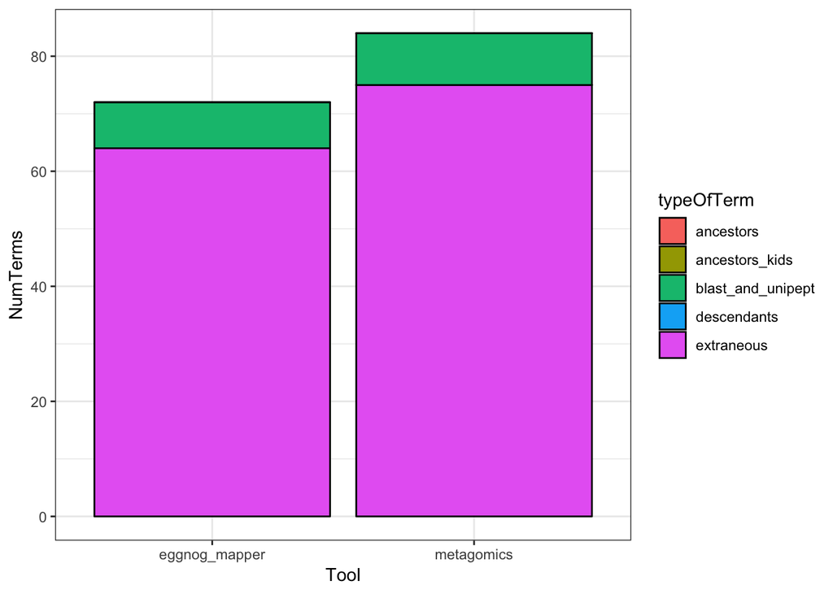

```r
term_df <- data.frame(
    typeOfTerm = rep(c("blast_and_unipept", "descendants", "ancestors", "ancestors_kids", "extraneous"), 2),
    NumTerms = c(em_num_buni, em_num_descendants, em_num_ancestors, em_num_ancestors_kids, em_num_extraneous,
             mg_num_buni, mg_num_descendants, mg_num_ancestors, mg_num_ancestors_kids, mg_num_extraneous),
    Tool = rep(c("eggnog_mapper", "metagomics"), each = 5)
)
library(ggplot2)
ggplot(term_df) +
    geom_bar(aes(x = Tool, y = NumTerms, fill = typeOfTerm), color = "black", stat = "identity") +
    theme_bw()
```

```r
head(get_go_names(em_buni))
```

[output not shown]

```r
head(get_go_names(mg_buni))
```

[output not shown]

```r
em_buni
```

```
## [1] "GO:0005737" "GO:0007268" "GO:0008344" "GO:0014059" "GO:0030424"
## [6] "GO:0043025" "GO:0046928" "GO:0050808"
```

```r
em_descendants
```

```
## character(0)
```

```r
head(get_go_names(em_descendants))
```

```r
head(get_go_names(mg_descendants))
```

```r
head(get_go_names(em_ancestors))
```

```r
head(get_go_names(mg_ancestors))
```

```r
head(get_go_names(em_extraneous))
```

[output not shown]

```r
head(get_go_names(mg_extraneous))
```

[output not shown]